# v1.9 (aff355d)

## Bowtie 2 / HiSAT2

[Bowtie 2](http://bowtie-bio.sourceforge.net/bowtie2/) and [HISAT2](https://ccb.jhu.edu/software/hisat2/) are fast and memory-efficient tools for aligning sequencing reads against a reference genome. Unfortunately both tools have identical log output by default, so it is impossible to distiguish which tool was used.

### Single-end alignments

This plot shows the number of reads aligning to the reference in different ways.

There are 3 possible types of alignment:

- **SE mapped uniquely**: Read has only one occurence in the reference genome.
- **SE multimapped**: Read has multiple occurence.
- **SE not aligned**: Read has no occurence.

Flat image plot. Toolbox functions such as highlighting / hiding samples will not work (see the [docs](http://multiqc.info/docs/#flat--interactive-plots)).

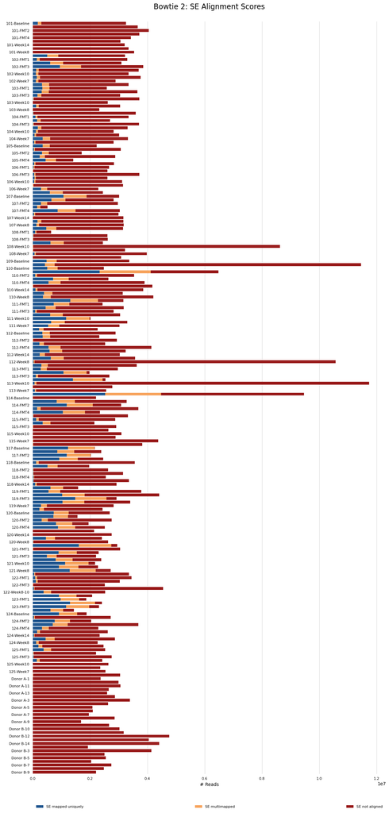

## fastp

fastp An ultra-fast all-in-one FASTQ preprocessor (QC, adapters, trimming, filtering, splitting...)

### Filtered Reads

Filtering statistics of sampled reads.

Flat image plot. Toolbox functions such as highlighting / hiding samples will not work (see the [docs](http://multiqc.info/docs/#flat--interactive-plots)).

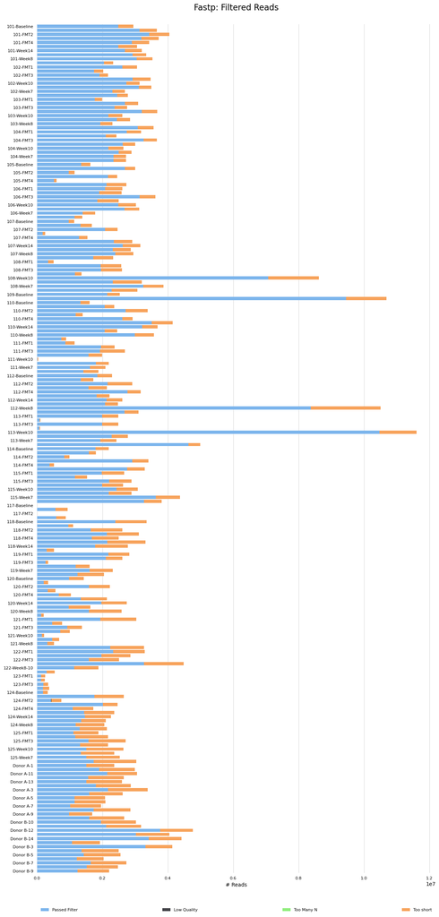

### Duplication Rates

Duplication rates of sampled reads.

Flat image plot. Toolbox functions such as highlighting / hiding samples will not work (see the [docs](http://multiqc.info/docs/#flat--interactive-plots)).

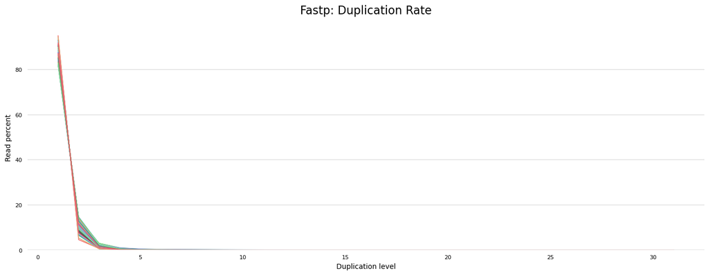